# Wearable technologies and biosignals for user studies [PS0000022]

Practical session #2 — Study design & data recording

University of Padova

## Today

**10:30–11:05** ⌚ Set up 20 devices and run our class experiment

**11:05–11:30** 🔎 Critically review the experimental protocol

**11:30–11:55** 👥 Develop your group’s wearable-based study protocol

**11:55–12:00** ✅ One design decision per group & wrap-up

## Our class experiment: digital interruptions

Digital interruptions during computer work 💻🔔

**Question:** How do interruptions relate to task performance, perceived workload, and physiological responses?

### Task 1 — Uninterrupted

- Excel **Worksheet A**
- No extra requests
- **3 minutes**

### Task 2 — Interrupted

We all complete the tasks **in the same order**. Afterward, we will evaluate what this means for the study’s validity.

## Your Excel task: check the tickets

For each customer-support ticket, enter **O** (OK) or **E** (Error).

**Rule 1:** High-priority tickets must receive a first reply within **2 hours**.

**Rule 2:** Normal-priority tickets must receive a first reply within **24 hours**.

**Rule 3:** Closed tickets must have a recorded first reply.

- Start from the **first row** and work down, without skipping rows.
- **Do not use** filters, formulas, or automatic checks.
- Aim for **accuracy**, not maximum speed.
- Stop when instructed; you are **not expected to finish 100 rows**.

## During Task 2: Zoom interruptions

The experimenter will send **four messages** at +1, +2, +3, and +4 minutes.

When a message appears:

1. **Pause** the Excel task.
2. Read the request and **reply privately** to the experimenter.
3. Resume Excel **where you left off**.

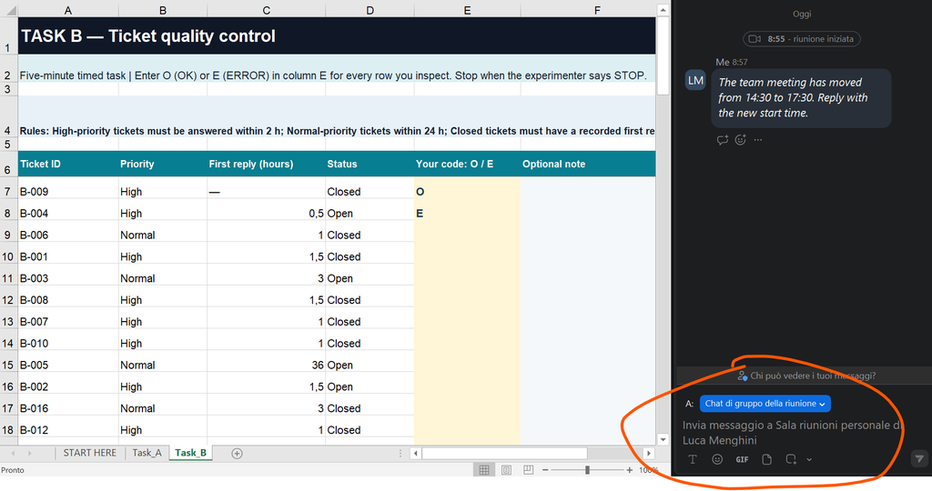

Keep the Zoom chat visible during **both** tasks. Silence microphones, speakers, and unrelated notifications.

## EmbracePlus setup

Download the Empatica Care App and follow the instruction in the printed paper assigned to your station.

[figure not shown]

## Before the recording: wearable checklist

### ⌚ EmbracePlus

- Wear on the **non-dominant wrist**, if possible.
- Ensure secure fit and **good skin contact**.
- Check that **recording is active**.
- Avoid adjusting the band during recording.

### 💻 Computer

- Excel workbook **open**; Task A ready
- Qualtrics questionnaire with your ID
- Zoom meeting and chat **open**
- Microphone and speakers **muted**
- No other notifications

## Event tags and the experiment log

**Press the EmbracePlus event-tag button when instructed**, at the start of each phase:

| **Tag** | **Phase starts** |
| --- | --- |
| **1** | Baseline |
| **2** | Task 1 — Uninterrupted |
| **3** | Task 2 — Interrupted |
| **4** | Recovery |

**Baseline**0–3 min

**Task 1**4–6 min

**Recovery**10–12 min

**Baseline:** Sit quietly, eyes open, hands resting.

**Task 1:** Check **Worksheet A** with no interruptions.

**Task 2:** Check **Worksheet B**; answer Zoom messages.

**Recovery:** Stop typing; sit quietly and avoid the computer.

**All participants start together.** Follow the instructor’s cues; do not anticipate a phase change.

## After recording: saving and sharing your excel sheet

- Save the completed Excel workbook by putting your anonymized ID code as the file name
- Upload the Excel sheet on the Google Drive folder linked on Moodle

## Critical review — be the reviewers

Peer review exercise 🔎

Imagine this experiment were submitted to a scientific journal. **Can any Task 1 vs Task 2 difference be attributed specifically to digital interruptions?**

## Debrief — what can we conclude?

### Design limitations

- Fixed order: **practice / fatigue**
- No rest between tasks: **carryover**
- Worksheet A vs B: **task equivalence**
- No separate recovery for each condition

### Measurement limitations

- Typing and tagging: **motion artefacts**
- Task-specific movement differences
- **Arousal ≠ stress**

The data can show **descriptive differences** between two consecutive tasks, but cannot isolate a **causal effect** of interruptions.

## Group project — design your own protocol

Return to the **user-study case** chosen in Practical Session #1.

In your group, produce a **one-page study protocol**:

| **Element** | **Define it clearly** |
| --- | --- |
| Research question | What do you want to test? |
| User task / conditions | What will participants do? |
| Sequence | What happens, and for how long? |
| Sensors / outcomes | What signals, behaviours and ratings? |
| Markers / log | How will you align events and signals? |
| Biggest confounder | What else could explain the results? |

## One design decision — and next session

### A one-minute update from each group

- What are your **conditions / study phases**?
- How will you **synchronize** the wearable data?
- Which **confounder** will you address first?

**Next session — Signal pre-processing in R:** align tags, inspect raw PPG and movement, identify artefacts, and assess data quality before extracting features.

[figure not shown]